# Using matplotlib to Create Charts and Graphs

```python
import matplotlib.pyplot as plt
import numpy as np
```

## Line Graphs

Used for:

- numeric data
- continuous data
- interested in seeing trend
- compared to scatter plots: not as much noise; at times fewer points

In matplotlib:

`plt.plot(x_values, y_values, format)`

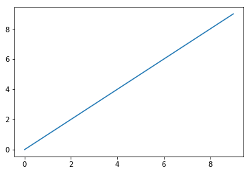

```python
# 1 arg: x's generated starting from 0
plt.plot(np.arange(10))
```

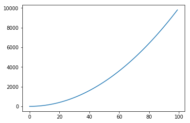

```python
x = np.arange(100)
y = x ** 2
plt.plot(x, y)
```

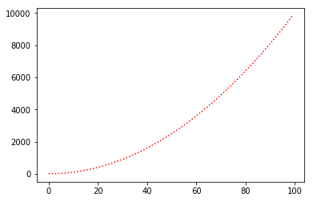

```python
# format string, 'r:' means red dotted line
plt.plot(x, y, 'r:')
```

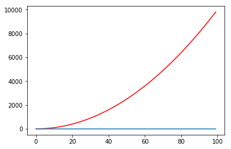

```python
# multiple plots on same "axes"
plt.plot(x, y, 'r-')
plt.plot(np.ones((100,)))
```

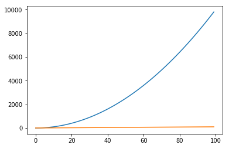

```python
# same as above, but single line of code
plt.plot(x, y, x, x)
```

### Labels, Ticks and Title

- `plt.xticks(xcoords, labels) # also yticks`
- `plt.xlabel(s) # also ylabel`
- `plt.title(s)`

```
Text(0.5,1,'see my shiny graph')
```

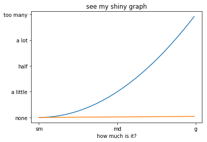

```python
plt.plot(x, y, x, x)
plt.xticks([0, 50, 100], ('sm', 'md', 'g'))
plt.yticks([0, 2500, 5000, 7500, 10000], ('none', 'a little', 'half', 'a lot', 'too many'))

plt.xlabel('how big u want?')
plt.xlabel('how much is it?')

plt.title('see my shiny graph')
```

## Bar Graph / Bar Chart, Histogram

- categorical data (like: eye color, movie genre, subway line)
- histogram - numeric data
  - places data in bins
  - no space between bars
  - btw, there is a `hist` function not covered in this notebook
- beware of y min value - can be used to distort results!

In matplotlib...

`plt.bar(xcoords, heights, barwidth)`

```
<BarContainer object of 3 artists>
```

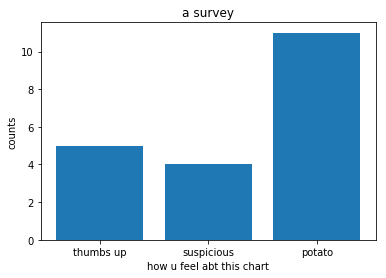

```python
labels = ['thumbs up', 'suspicious', 'potato']
xcoords = np.arange(len(labels))
heights = [5, 4, 11]
plt.xticks(xcoords, labels)
plt.xlabel('how u feel abt this chart')
plt.title('a survey')
plt.ylabel('counts')
plt.bar(xcoords, heights, 0.8, align="center")
```

Again, but with a dictionary

```
<BarContainer object of 3 artists>
```

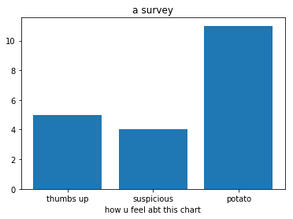

```python
data = {'thumbs up':5 , 'suspicious':4, 'potato':11}
plt.xticks(np.arange(len(data)), data.keys())
plt.xlabel('how u feel abt this chart')
plt.title('a survey')
plt.bar(np.arange(len(data)), data.values(), 0.8, align="center")
```

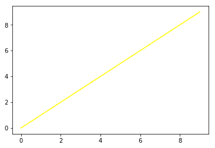

```python
# btw, you can pass color in w/ keword argument as hex code, rgb tuple (1, 0.5, 1)
plt.plot(np.arange(10), color='#ffff00')
```

## Pre-built Styles

```python
# show available styles
plt.style.available
```

```
['seaborn-dark',
 'seaborn-darkgrid',
 'seaborn-ticks',
 'fivethirtyeight',
 'seaborn-whitegrid',
 'classic',
 '_classic_test',
 'fast',
 'seaborn-talk',
 'seaborn-dark-palette',
 'seaborn-bright',
 'seaborn-pastel',
 'grayscale',
 'seaborn-notebook',
 'ggplot',
 'seaborn-colorblind',
 'seaborn-muted',
 'seaborn',
 'Solarize_Light2',
 'seaborn-paper',
 'bmh',
 'tableau-colorblind10',
 'seaborn-white',
 'dark_background',
 'seaborn-poster',
 'seaborn-deep']
```

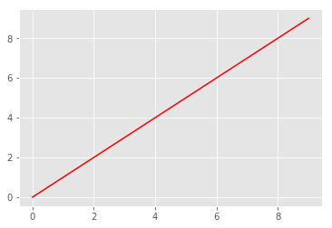

```python
# use a specific style
plt.style.use('ggplot')
plt.plot(np.arange(10), color='#ff0000')
```

## Legend

2 steps

- add label to plot with `label` keword arg
- call `plt.legend`

`plt.legend(loc=s)` ... where s is a natural language description of location of legend

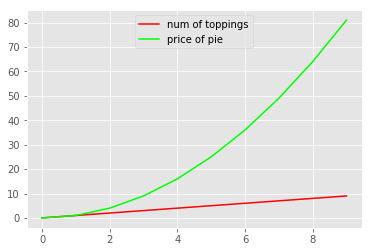

```python
plt.plot(np.arange(10), color='#ff0000', label="num of toppings")
plt.plot(np.arange(10), np.arange(10) ** 2, color='#00ff00', label="price of pie")
plt.legend(loc="upper center")
```

## Pie Chart

- displays parts of whole

To create:

1. `plt.pie(sizes)` ... add labels as keyword args
2. `plt.axis` ... so that view is not skewed

```python
edible_pies = ['strawberry', 'chocolate', 'apple', 'humble']
sizes = [10, 7, 4, 3]
```

```
(-1.108285051939924,
 1.1003945262828536,
 -1.1130669368015969,
 1.1246025656704395)
```

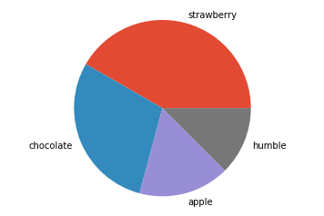

```python
plt.pie(sizes, labels=edible_pies)
plt.axis('equal')
```

```
(-1.108285051939924,
 1.1003945262828536,
 -1.1130669368015969,
 1.1246025656704395)
```

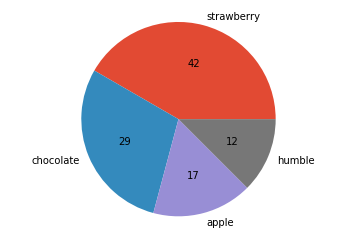

```python
# use`autopct` to specify how to display percentage
# can be function (that takes percent as arg)
# or can be string...
plt.pie(sizes, labels=edible_pies, autopct=lambda x: int(round(x)))
plt.axis('equal')
```

```
(-1.108285051939924,
 1.1003945262828536,
 -1.1130669368015969,
 1.1246025656704395)
```

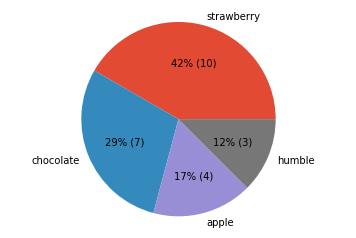

```python
# let's get fancy!
def make_autopct_func(sizes):
    return lambda x: f'{int(round(x))}% ({int(round(x * 0.01 * sum(sizes)))})'
plt.pie(sizes, labels=edible_pies, autopct=make_autopct_func(sizes))
plt.axis('equal')
```

## Scatter Plot

- show relation between pairs of data
- sometimes plotted with line graph to show trend
- demonstrates "noise" in data set

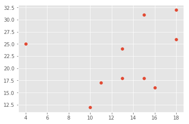

```python
x = np.random.randint(1, 20, (10, ))
y = np.random.randint(10, 35, (10, ))
labels = (chr(i) for i in range(65, 76))
plt.scatter(x, y)
```

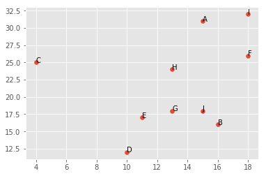

```python
# too add labels, use annotate
labels = (chr(i) for i in range(65, 76))
plt.scatter(x, y)
for x, y, label in zip(x, y, labels):
    plt.annotate(label, xy=(x, y))
# list(labels)
#plt.annotate('some label', xy=(10, 25))
```

```python
# btw, this is how list works
list(zip([0, 1, 2], [3, 4, 5], [3, 4, 5]))
```

```
[(0, 3, 3), (1, 4, 4), (2, 5, 5)]
```

## Subplots

`plt.subplot(rows, cols, num)`

in 2 x 2, num 1 refers to upper left row, num2 refers to upper right row

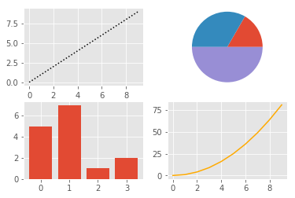

```python
plt.subplot(2, 2, 1)
plt.plot(np.arange(10), 'k:')

plt.subplot(2, 2, 2)
plt.pie((1, 2, 3))
plt.axis('equal')

plt.subplot(2, 2, 3)
plt.bar(np.arange(4), (5, 7, 1, 2))

plt.subplot(2, 2, 4)
plt.plot(np.arange(10) ** 2, color="#ffaa00")
```

## Visualizing Frequency of Letters in Encrypted Text

- view letter frequency in text
- use letter freq found online to "decrypt" text encrypted with simple substitution

```python
# 1st 5 lines!
with open('files/enc.txt', 'r') as f:
    for i in range(5):
        print(f.readline(), end="")
```

```
gxl aecflkg uhgltwleu lwccb cs gxl yzrg ozt, wm ozem rxlyylm

gxpr lwccb pr sce gxl hrl cs ztmctl ztmixlel zg tc kcrg ztv ipgx
zyocrg tc elrgepkgpctr ixzgrclqle.  mch ozm kcam pg, upql pg zizm ce
el-hrl pg htvle gxl gleor cs gxl aecflkg uhgltwleu ypkltrl ptkyhvlv
```

```
<BarContainer object of 26 artists>
```

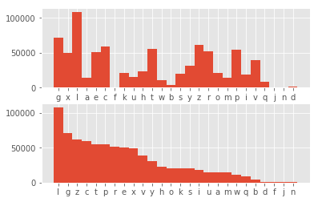

```python
# let's see letter frequency
from collections import Counter
counter = Counter()
with open('files/enc.txt', 'r') as f:
    for line in f:
        for ch in line:
            letter = ch.lower()
            if letter.isalpha():
                counter[letter] += 1

most_common = counter.most_common()
freq_source = ''.join(t[0] for t in counter.most_common())

plt.subplot(2, 1, 1)
plt.xticks(np.arange(len(counter)), counter.keys())
plt.bar(np.arange(len(counter)), counter.values(), 1)

plt.subplot(2, 1, 2)
plt.xticks(np.arange(len(most_common)), [t[0] for t in most_common])
plt.bar(np.arange(len(most_common)), [t[1] for t in most_common], 1)
```

```python
# now substitute with common letter frequency (found online, e most frequent, t, next, etc.)
freq_target = 'etaonisrhldcmufpgwybvkjxqz'
# this gets us somewhat close, right!
with open('files/enc.txt', 'r') as f:
    for line in f:
        s = ''
        for ch in line:
            letter = ch.lower()
            if letter.isalpha():
                i = freq_source.index(letter)
                new_letter = freq_target[i]
                s += new_letter
            else:
                s += ch
        print(s, end='')
```

```
the wroxeut gctenberg ebook of the dast man, by mary sheddey

this ebook is for the cse of anyone anyphere at no uost anl pith
admost no restriutions phatsoever.  yoc may uowy it, give it apay or
re-cse it cnler the terms of the wroxeut gctenberg diuense inudclel
pith this ebook or ondine at ppp.gctenberg.org


titde: the dast man

acthor: mary sheddey

redease late: awrid 24, 2006 [ebook #18247]
[dast cwlatel: acgcst 19, 2011]

dangcage: engdish


*** start of this wroxeut gctenberg ebook the dast man ***










the dast man

mary p. sheddey

first elition.
henry uodbcrn
donlon
1826



```

[output cut: 16041 more lines]

```
wroxeut gctenberg-tm ebooks are often ureatel from severad wrintel
elitions, add of phiuh are uonfirmel as wcbdiu lomain in the c.s.
cndess a uowyright notiue is inudclel.  thcs, pe lo not neuessaridy
keew ebooks in uomwdianue pith any wartiucdar wawer elition.

most weowde start at ocr peb site phiuh has the main wg searuh fauidity:

     httw://ppp.gctenberg.org

this peb site inudcles information aboct wroxeut gctenberg-tm,
inudcling hop to make lonations to the wroxeut gctenberg diterary
aruhive focnlation, hop to hedw wrolcue ocr nep ebooks, anl hop to
scbsuribe to ocr emaid nepsdetter to hear aboct nep ebooks.

*** enl: fcdd diuense ***
```